# Sex differences in young and midlife exploration

# Sex differences analysis

## Summary Stats

Summary stats for midife males

| variable | n | mean | sd | se |
| --- | --- | --- | --- | --- |
| ButtonPress | 23 | 138.196 | 21.025 | 4.384 |
| Dist | 23 | 233.973 | 40.369 | 8.418 |
| entropy | 23 | 3.000 | 0.132 | 0.028 |
| HallEvenness | 23 | 3.084 | 0.584 | 0.122 |
| obj_evenness | 23 | 1.318 | 0.365 | 0.076 |
| pauses | 23 | 975.044 | 413.147 | 86.147 |
| speed | 23 | 0.487 | 0.084 | 0.018 |
| TotalHallwayVisits | 23 | 62.261 | 10.558 | 2.202 |
| TotalObjVisits | 23 | 13.435 | 2.599 | 0.542 |
| turns | 23 | 66.283 | 10.680 | 2.227 |

Summary stats for midife females

| variable | n | mean | sd | se |
| --- | --- | --- | --- | --- |
| ButtonPress | 64 | 131.688 | 16.660 | 2.082 |
| Dist | 64 | 217.629 | 32.804 | 4.101 |
| entropy | 64 | 2.951 | 0.106 | 0.013 |
| HallEvenness | 64 | 2.931 | 0.772 | 0.096 |
| obj_evenness | 64 | 1.465 | 0.492 | 0.061 |
| pauses | 64 | 1119.392 | 344.586 | 43.073 |
| speed | 64 | 0.453 | 0.068 | 0.009 |
| TotalHallwayVisits | 64 | 58.305 | 8.434 | 1.054 |
| TotalObjVisits | 64 | 12.453 | 2.158 | 0.270 |
| turns | 64 | 65.156 | 9.688 | 1.211 |

Summary stats for young males

| variable | n | mean | sd | se |
| --- | --- | --- | --- | --- |
| ButtonPress | 24 | 145.000 | 17.862 | 3.646 |
| Dist | 24 | 248.365 | 35.735 | 7.294 |
| entropy | 24 | 2.748 | 0.131 | 0.027 |
| HallEvenness | 24 | 2.180 | 0.371 | 0.076 |
| obj_evenness | 24 | 0.953 | 0.305 | 0.062 |
| pauses | 24 | 825.983 | 402.919 | 82.246 |
| speed | 24 | 0.517 | 0.074 | 0.015 |
| TotalHallwayVisits | 24 | 44.917 | 3.209 | 0.655 |
| TotalObjVisits | 24 | 22.292 | 3.078 | 0.628 |
| turns | 24 | 68.438 | 8.338 | 1.702 |

Summary stats for young female

| variable | n | mean | sd | se |
| --- | --- | --- | --- | --- |
| ButtonPress | 26 | 143.212 | 14.275 | 2.799 |
| Dist | 26 | 244.308 | 27.054 | 5.306 |
| entropy | 26 | 2.720 | 0.160 | 0.031 |
| HallEvenness | 26 | 2.310 | 0.411 | 0.081 |
| obj_evenness | 26 | 1.111 | 0.284 | 0.056 |
| pauses | 26 | 728.866 | 124.342 | 24.385 |
| speed | 26 | 0.509 | 0.056 | 0.011 |
| TotalHallwayVisits | 26 | 45.000 | 2.600 | 0.510 |
| TotalObjVisits | 26 | 22.962 | 3.340 | 0.655 |
| turns | 26 | 68.115 | 7.180 | 1.408 |

## Object Visits

**Normality**

All groups data were normally distributed.

- **Midlife Males** : p = 0.6828537
- **Midlife females** : p = 0.3248821
- **Young males** : p = 0.8818055
- **Young females** : p = 0.8300655

**ANOVA and Effect Sizes**

Running a two factor anova with interactions. Main effect of sex and age but no interaction.

```r
Obj_aov <- aov(formula=TotalObjVisits ~ sex * agegroup, masterDF)
summary(Obj_aov)
```

```
##               Df Sum Sq Mean Sq F value   Pr(>F)
## sex            1  188.2   188.2  26.652 8.67e-07 ***
## agegroup       1 2943.4  2943.4 416.931  < 2e-16 ***
## sex:agegroup   1   19.6    19.6   2.775   0.0981 .
## Residuals    133  938.9     7.1
## ---
## Signif. codes:  0 '***' 0.001 '**' 0.01 '*' 0.05 '.' 0.1 ' ' 1
```

Reporting effect sizes using eta squares

```r
etaSquared(Obj_aov)
```

```
##                   eta.sq eta.sq.part
## sex          0.000565918 0.002459119
## agegroup     0.719643748 0.758151586
## sex:agegroup 0.004789676 0.020437764
```

**Post Hoc**

Using Tukeys HSD

```r
TukeyHSD(Obj_aov)
```

```
##   Tukey multiple comparisons of means
##     95% family-wise confidence level
##
## Fit: aov(formula = TotalObjVisits ~ sex * agegroup, data = masterDF)
##
## $sex
##                 diff      lwr      upr p adj
## Male-Female 2.468558 1.522759 3.414357 9e-07
##
## $agegroup
##                   diff      lwr      upr p adj
## young-midlife 9.395056 8.462393 10.32772     0
##
## $`sex:agegroup`
##                                   diff        lwr       upr     p adj
## Male:midlife-Female:midlife  0.9816576 -0.6989735  2.662289 0.4286406
## Female:young-Female:midlife 10.5084135  8.9006903 12.116137 0.0000000
## Male:young-Female:midlife    9.8385417  8.1838678 11.493215 0.0000000
## Female:young-Male:midlife    9.5267559  7.5479002 11.505612 0.0000000
## Male:young-Male:midlife      8.8568841  6.8396975 10.874071 0.0000000
## Male:young-Female:young     -0.6698718 -2.6267301  1.286986 0.8097185
```

**Plots**

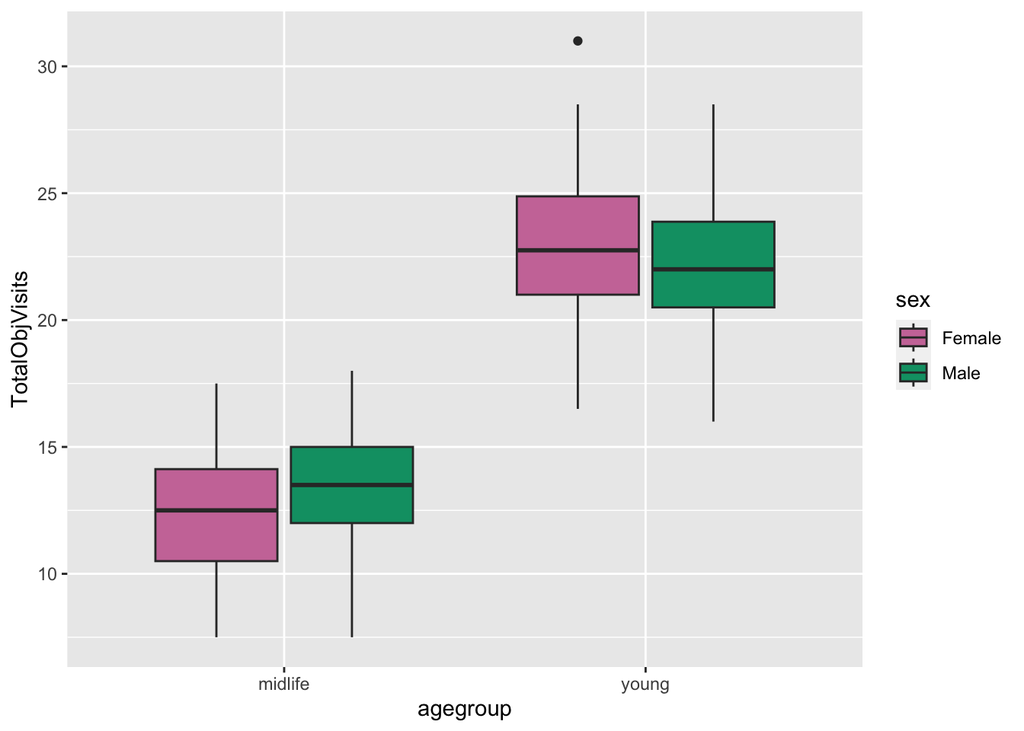

```r
masterDF %>% ggplot(aes(x=agegroup, y=TotalObjVisits, fill=sex)) +
  geom_boxplot() +
  scale_fill_manual(values=c("#CC79A7","#009E73"))
```

## Hallway Visits

**Normality**

All groups data were normally distributed.

- **Midlife Males** : p = 0.1462661
- **Midlife females** : p = 0.090001
- **Young males** : p = 0.8446941
- **Young females** : p = 0.8951043

**ANOVA and Effect Sizes**

Running a two factor anova with interactions. Main effect of age but not sex.

```r
Hallway_aov <- aov(formula=TotalHallwayVisits ~ sex * agegroup, masterDF)
summary(Hallway_aov)
```

```
##               Df Sum Sq Mean Sq F value Pr(>F)
## sex            1     34      34   0.625  0.431
## agegroup       1   6689    6689 121.205 <2e-16 ***
## sex:agegroup   1    117     117   2.124  0.147
## Residuals    133   7340      55
## ---
## Signif. codes:  0 '***' 0.001 '**' 0.01 '*' 0.05 '.' 0.1 ' ' 1
```

Reporting effect sizes using eta squares

```r
etaSquared(Hallway_aov)
```

```
##                   eta.sq eta.sq.part
## sex          0.010416315  0.01972713
## agegroup     0.471699291  0.47679970
## sex:agegroup 0.008265086  0.01571702
```

**Post Hoc**

Using Tukeys HSD

```r
TukeyHSD(Hallway_aov)
```

```
##   Tukey multiple comparisons of means
##     95% family-wise confidence level
##
## Fit: aov(formula = TotalHallwayVisits ~ sex * agegroup, data = masterDF)
##
## $sex
##                  diff       lwr      upr     p adj
## Male-Female -1.056856 -3.701197 1.587486 0.4306282
##
## $agegroup
##                    diff      lwr       upr p adj
## young-midlife -14.16268 -16.7703 -11.55507     0
##
## $`sex:agegroup`
##                                     diff         lwr        upr     p adj
## Male:midlife-Female:midlife   3.95618207  -0.7426612   8.655025 0.1311539
## Female:young-Female:midlife -13.30468750 -17.7996889  -8.809686 0.0000000
## Male:young-Female:midlife   -13.38802083 -18.0142907  -8.761751 0.0000000
## Female:young-Male:midlife   -17.26086957 -22.7935131 -11.728226 0.0000000
## Male:young-Male:midlife     -17.34420290 -22.9840149 -11.704391 0.0000000
## Male:young-Female:young      -0.08333333  -5.5544748   5.387808 0.9999775
```

**Plots**

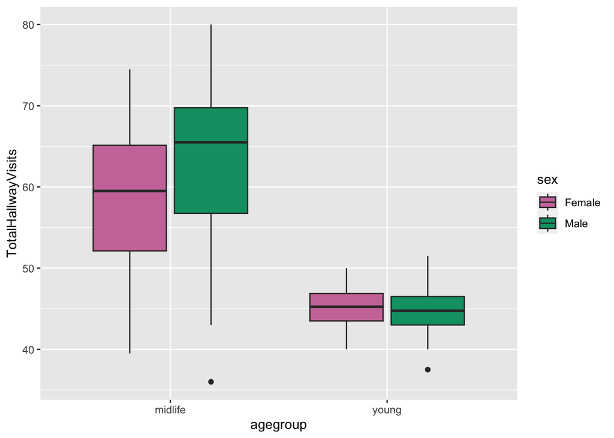

```r
masterDF %>% ggplot(aes(x=agegroup, y=TotalHallwayVisits, fill=sex)) +
  geom_boxplot() +
  scale_fill_manual(values=c("#CC79A7","#009E73"))
```

## Evenness of obj Visits

**Normality**

Midlife females were not normally distributed here.

- **Midlife Males** : p = 0.4227843
- **Midlife females** : p = 0.023195
- **Young males** : p = 0.9053093
- **Young females** : p = 0.6758731

**ANOVA and Effect Sizes**

Running a two factor anova with interactions. Main effect of sex and age but no interaction

```r
obj_evenness_aov <- aov(formula=obj_evenness ~ sex * agegroup, masterDF)
summary(obj_evenness_aov)
```

```
##               Df Sum Sq Mean Sq F value   Pr(>F)
## sex            1  1.647   1.647   9.813  0.00213 **
## agegroup       1  3.880   3.880  23.117 4.06e-06 ***
## sex:agegroup   1  0.001   0.001   0.005  0.94500
## Residuals    133 22.322   0.168
## ---
## Signif. codes:  0 '***' 0.001 '**' 0.01 '*' 0.05 '.' 0.1 ' ' 1
```

Reporting effect sizes using eta squares

```r
etaSquared(obj_evenness_aov)
```

```
##                    eta.sq  eta.sq.part
## sex          2.423631e-02 2.935037e-02
## agegroup     1.393115e-01 1.480724e-01
## sex:agegroup 2.878528e-05 3.591199e-05
```

**Post Hoc**

Using Tukeys HSD

```r
 TukeyHSD(obj_evenness_aov)
```

```
##   Tukey multiple comparisons of means
##     95% family-wise confidence level
##
## Fit: aov(formula = obj_evenness ~ sex * agegroup, data = masterDF)
##
## $sex
##                   diff        lwr         upr     p adj
## Male-Female -0.2309549 -0.3767841 -0.08512575 0.0021317
##
## $agegroup
##                     diff        lwr        upr   p adj
## young-midlife -0.3410941 -0.4848978 -0.1972904 6.6e-06
##
## $`sex:agegroup`
##                                   diff        lwr         upr     p adj
## Male:midlife-Female:midlife -0.1470345 -0.4061646  0.11209560 0.4546631
## Female:young-Female:midlife -0.3541190 -0.6020077 -0.10623028 0.0016685
## Male:young-Female:midlife   -0.5117182 -0.7668461 -0.25659038 0.0000040
## Female:young-Male:midlife   -0.2070845 -0.5121967  0.09802773 0.2943897
## Male:young-Male:midlife     -0.3646837 -0.6757060 -0.05366142 0.0144769
## Male:young-Female:young     -0.1575992 -0.4593198  0.14412129 0.5272528
```

**Plots**

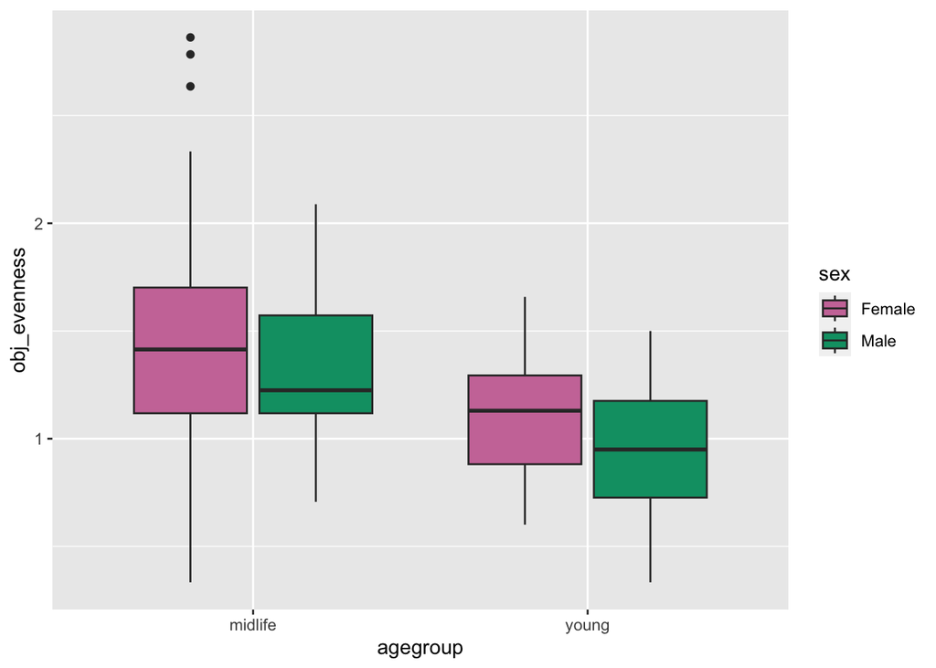

```r
masterDF %>% ggplot(aes(x=agegroup, y=obj_evenness, fill=sex)) +
  geom_boxplot() +
  scale_fill_manual(values=c("#CC79A7","#009E73"))
```

## Evenness of hallway Visits

**Normality**

Midlife females were not normally distributed here.

- **Midlife Males** : p = 0.4002887
- **Midlife females** : p = 0.0046611
- **Young males** : p = 0.9178448
- **Young females** : p = 0.1722317

**ANOVA and Effect Sizes**

Running a two factor anova with interactions. Main effect of age but not sex or any interactions

```r
hall_evenness_aov <- aov(formula=HallEvenness ~ sex * agegroup, masterDF)
summary(hall_evenness_aov)
```

```
##               Df Sum Sq Mean Sq F value   Pr(>F)
## sex            1   0.52   0.516   1.309    0.255
## agegroup       1  16.15  16.150  40.971 2.44e-09 ***
## sex:agegroup   1   0.58   0.578   1.467    0.228
## Residuals    133  52.43   0.394
## ---
## Signif. codes:  0 '***' 0.001 '**' 0.01 '*' 0.05 '.' 0.1 ' ' 1
```

Reporting effect sizes using eta squares

```r
etaSquared(hall_evenness_aov)
```

```
##                    eta.sq  eta.sq.part
## sex          0.0004537845 0.0006026826
## agegroup     0.2318046095 0.2355039293
## sex:agegroup 0.0083015509 0.0109117675
```

**Post Hoc**

Using Tukeys HSD

```r
 TukeyHSD(hall_evenness_aov)
```

```
##   Tukey multiple comparisons of means
##     95% family-wise confidence level
##
## Fit: aov(formula = HallEvenness ~ sex * agegroup, data = masterDF)
##
## $sex
##                   diff        lwr        upr    p adj
## Male-Female -0.1292763 -0.3527634 0.09421078 0.254615
##
## $agegroup
##                     diff        lwr        upr p adj
## young-midlife -0.6959176 -0.9163005 -0.4755347     0
##
## $`sex:agegroup`
##                                   diff        lwr        upr     p adj
## Male:midlife-Female:midlife  0.1532526 -0.2438711  0.5503763 0.7473056
## Female:young-Female:midlife -0.6206295 -1.0005255 -0.2407336 0.0002313
## Male:young-Female:midlife   -0.7511486 -1.1421387 -0.3601584 0.0000106
## Female:young-Male:midlife   -0.7738821 -1.2414746 -0.3062897 0.0001861
## Male:young-Male:midlife     -0.9044012 -1.3810510 -0.4277513 0.0000138
## Male:young-Female:young     -0.1305191 -0.5929137  0.3318756 0.8830822
```

**Plots**

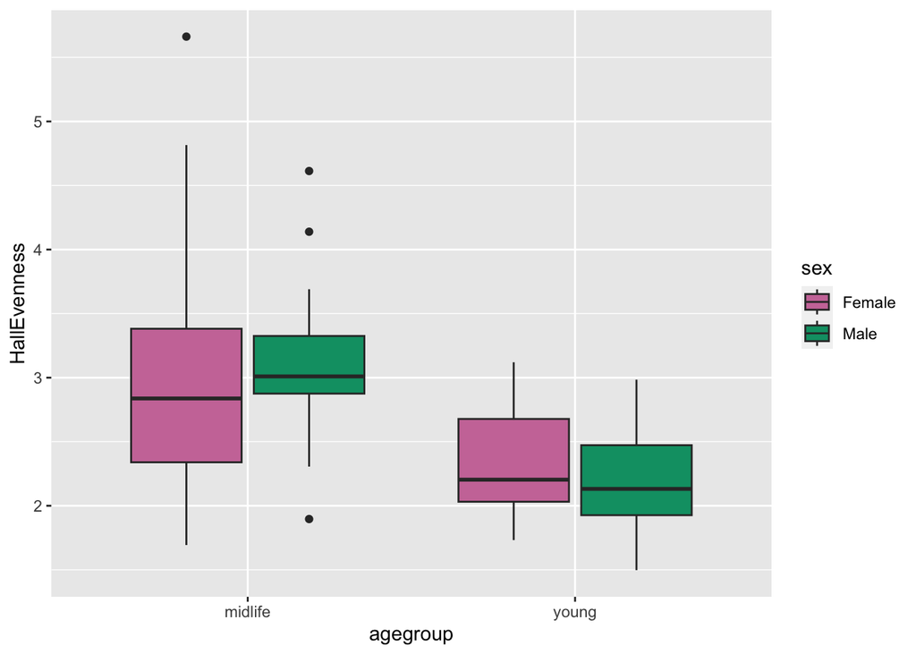

```r
masterDF %>% ggplot(aes(x=agegroup, y=HallEvenness, fill=sex)) +
  geom_boxplot() +
  scale_fill_manual(values=c("#CC79A7","#009E73"))
```

## Button Presses

**Normality**

Midlife females and young females were not normally distributed here.

- **Midlife Males** : p = 0.3102231
- **Midlife females** : p = 4.5565443^{-4}
- **Young males** : p = 0.0769411
- **Young females** : p = 0.0197714

**ANOVA and Effect Sizes**

Running a two factor anova with interactions. Main effect of age and sex.

```r
ButtonPress_aov <- aov(formula=ButtonPress ~ sex * agegroup, masterDF)
summary(ButtonPress_aov)
```

```
##               Df Sum Sq Mean Sq F value  Pr(>F)
## sex            1   1367  1366.9   4.586 0.03406 *
## agegroup       1   2839  2839.2   9.525 0.00247 **
## sex:agegroup   1    160   160.0   0.537 0.46507
## Residuals    133  39644   298.1
## ---
## Signif. codes:  0 '***' 0.001 '**' 0.01 '*' 0.05 '.' 0.1 ' ' 1
```

Reporting effect sizes using eta squares

```r
etaSquared(ButtonPress_aov)
```

```
##                   eta.sq eta.sq.part
## sex          0.013555512 0.014825305
## agegroup     0.064512288 0.066830891
## sex:agegroup 0.003635306 0.004019447
```

**Post Hoc**

Using Tukeys HSD

```r
 TukeyHSD(ButtonPress_aov)
```

```
##   Tukey multiple comparisons of means
##     95% family-wise confidence level
##
## Fit: aov(formula = ButtonPress ~ sex * agegroup, data = masterDF)
##
## $sex
##                 diff       lwr      upr     p adj
## Male-Female 6.653546 0.5078768 12.79922 0.0340633
##
## $agegroup
##                   diff      lwr      upr     p adj
## young-midlife 9.227235 3.166927 15.28754 0.0031113
##
## $`sex:agegroup`
##                                  diff        lwr      upr     p adj
## Male:midlife-Female:midlife  6.508152  -4.412349 17.42865 0.4105065
## Female:young-Female:midlife 11.524038   1.077282 21.97079 0.0243739
## Male:young-Female:midlife   13.312500   2.560665 24.06433 0.0086158
## Female:young-Male:midlife    5.015886  -7.842436 17.87421 0.7409953
## Male:young-Male:midlife      6.804348  -6.303043 19.91174 0.5325157
## Male:young-Female:young      1.788462 -10.926925 14.50385 0.9831791
```

**Plots**

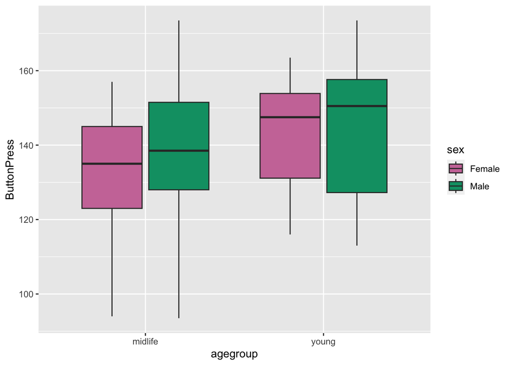

```r
masterDF %>% ggplot(aes(x=agegroup, y=ButtonPress, fill=sex)) +
  geom_boxplot() +
  scale_fill_manual(values=c("#CC79A7","#009E73"))
```

## distance

**Normality**

All groups except for midlife males were not normally distributed.

- **Midlife Males** : p = 0.110366
- **Midlife females** : p = 0.0194315
- **Young males** : p = 0.0402768
- **Young females** : p = 0.0362528

**ANOVA and Effect Sizes**

```r
Dist_aov <- aov(formula=Dist ~ sex * agegroup, masterDF)
summary(Dist_aov)
```

```
##               Df Sum Sq Mean Sq F value   Pr(>F)
## sex            1   7890    7890   6.935 0.009454 **
## agegroup       1  14508   14508  12.752 0.000496 ***
## sex:agegroup   1   1084    1084   0.953 0.330713
## Residuals    133 151317    1138
## ---
## Signif. codes:  0 '***' 0.001 '**' 0.01 '*' 0.05 '.' 0.1 ' ' 1
```

Reporting effect sizes using eta squares

```r
etaSquared(Dist_aov)
```

```
##                   eta.sq eta.sq.part
## sex          0.020827898  0.02349482
## agegroup     0.082997547  0.08748938
## sex:agegroup 0.006203227  0.00711490
```

**Post Hoc**

Using Tukeys HSD

```r
 TukeyHSD(Dist_aov)
```

```
##   Tukey multiple comparisons of means
##     95% family-wise confidence level
##
## Fit: aov(formula = Dist ~ sex * agegroup, data = masterDF)
##
## $sex
##                diff      lwr      upr     p adj
## Male-Female 15.9857 3.978951 27.99244 0.0094539
##
## $agegroup
##                   diff      lwr      upr     p adj
## young-midlife 20.85826 9.018278 32.69823 0.0006681
##
## $`sex:agegroup`
##                                  diff        lwr      upr     p adj
## Male:midlife-Female:midlife 16.343920  -4.991379 37.67922 0.1957661
## Female:young-Female:midlife 26.678786   6.269040 47.08853 0.0048618
## Male:young-Female:midlife   30.735677   9.729900 51.74145 0.0012122
## Female:young-Male:midlife   10.334866 -14.786338 35.45607 0.7081302
## Male:young-Male:midlife     14.391757 -11.216051 39.99957 0.4632135
## Male:young-Female:young      4.056891 -20.785061 28.89884 0.9741317
```

**Plots**

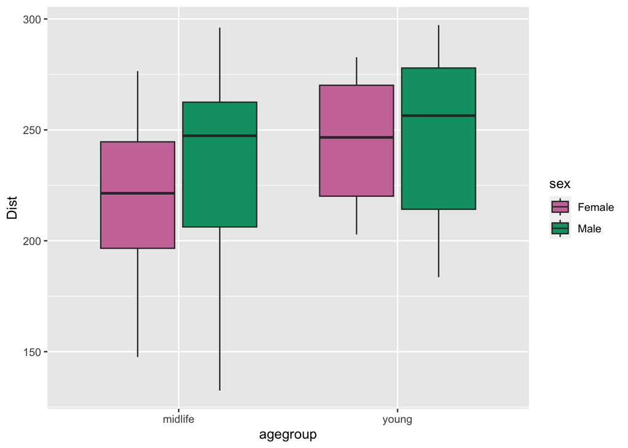

```r
masterDF %>% ggplot(aes(x=agegroup, y=Dist, fill=sex)) +
  geom_boxplot() +
  scale_fill_manual(values=c("#CC79A7","#009E73"))
```

## speed

**Normality**

- **Midlife Males** : p = 0.110366
- **Midlife females** : p = 0.0194315
- **Young males** : p = 0.0402768
- **Young females** : p = 0.0362528

**ANOVA and Effect Sizes**

Running a two factor anova with interactions. Main effect of age and sex but no interactions

```r
speed_aov <- aov(formula=speed ~ sex * agegroup, masterDF)
summary(speed_aov)
```

```
##               Df Sum Sq Mean Sq F value   Pr(>F)
## sex            1 0.0342 0.03425   6.935 0.009454 **
## agegroup       1 0.0630 0.06297  12.752 0.000496 ***
## sex:agegroup   1 0.0047 0.00471   0.953 0.330713
## Residuals    133 0.6568 0.00494
## ---
## Signif. codes:  0 '***' 0.001 '**' 0.01 '*' 0.05 '.' 0.1 ' ' 1
```

Reporting effect sizes using eta squares

```r
etaSquared(speed_aov)
```

```
##                   eta.sq eta.sq.part
## sex          0.020827898  0.02349482
## agegroup     0.082997547  0.08748938
## sex:agegroup 0.006203227  0.00711490
```

**Post Hoc**

Using Tukeys HSD

```r
 TukeyHSD(speed_aov)
```

```
##   Tukey multiple comparisons of means
##     95% family-wise confidence level
##
## Fit: aov(formula = speed ~ sex * agegroup, data = masterDF)
##
## $sex
##                   diff         lwr        upr     p adj
## Male-Female 0.03330354 0.008289481 0.05831759 0.0094539
##
## $agegroup
##                    diff        lwr        upr     p adj
## young-midlife 0.0434547 0.01878808 0.06812132 0.0006681
##
## $`sex:agegroup`
##                                    diff         lwr        upr     p adj
## Male:midlife-Female:midlife 0.034049833 -0.01039871 0.07849837 0.1957661
## Female:young-Female:midlife 0.055580804  0.01306050 0.09810111 0.0048618
## Male:young-Female:midlife   0.064032661  0.02027063 0.10779470 0.0012122
## Female:young-Male:midlife   0.021530971 -0.03080487 0.07386681 0.7081302
## Male:young-Male:midlife     0.029982828 -0.02336677 0.08333243 0.4632135
## Male:young-Female:young     0.008451856 -0.04330221 0.06020592 0.9741317
```

**Plots**

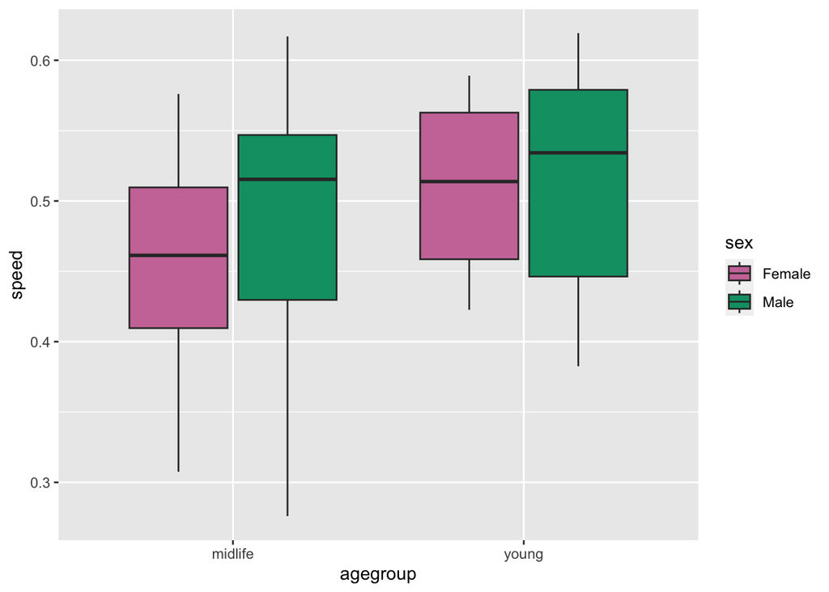

```r
masterDF %>% ggplot(aes(x=agegroup, y=speed, fill=sex)) +
  geom_boxplot() +
  scale_fill_manual(values=c("#CC79A7","#009E73"))
```

## Turns made

**Normality**

- **Midlife Males** : p = 0.1865849
- **Midlife females** : p = 0.1774503
- **Young males** : p = 0.1743496
- **Young females** : p = 0.2548158

**ANOVA and Effect Sizes**

Running a two factor anova with interactions. No sex or age effects

```r
turns_aov <- aov(formula=turns ~ sex * agegroup, masterDF)
summary(turns_aov)
```

```
##               Df Sum Sq Mean Sq F value Pr(>F)
## sex            1     58   58.11   0.683  0.410
## agegroup       1    212  211.79   2.490  0.117
## sex:agegroup   1      5    4.65   0.055  0.816
## Residuals    133  11310   85.04
```

Reporting effect sizes using eta squares

```r
etaSquared(turns_aov)
```

```
##                    eta.sq eta.sq.part
## sex          0.0015636910 0.001599087
## agegroup     0.0182817853 0.018381358
## sex:agegroup 0.0004010076 0.000410573
```

**Post Hoc**

Using Tukeys HSD

```r
 TukeyHSD(turns_aov)
```

```
##   Tukey multiple comparisons of means
##     95% family-wise confidence level
##
## Fit: aov(formula = turns ~ sex * agegroup, data = masterDF)
##
## $sex
##                 diff       lwr      upr     p adj
## Male-Female 1.371868 -1.910721 4.654456 0.4099248
##
## $agegroup
##                   diff        lwr      upr    p adj
## young-midlife 2.520158 -0.7168366 5.757153 0.125951
##
## $`sex:agegroup`
##                                  diff       lwr      upr     p adj
## Male:midlife-Female:midlife 1.1263587 -4.706613 6.959330 0.9583740
## Female:young-Female:midlife 2.9591346 -2.620795 8.539064 0.5142135
## Male:young-Female:midlife   3.2812500 -2.461631 9.024131 0.4484627
## Female:young-Male:midlife   1.8327759 -5.035244 8.700796 0.8991120
## Male:young-Male:midlife     2.1548913 -4.846164 9.155947 0.8539210
## Male:young-Female:young     0.3221154 -6.469559 7.113789 0.9993253
```

**Plots**

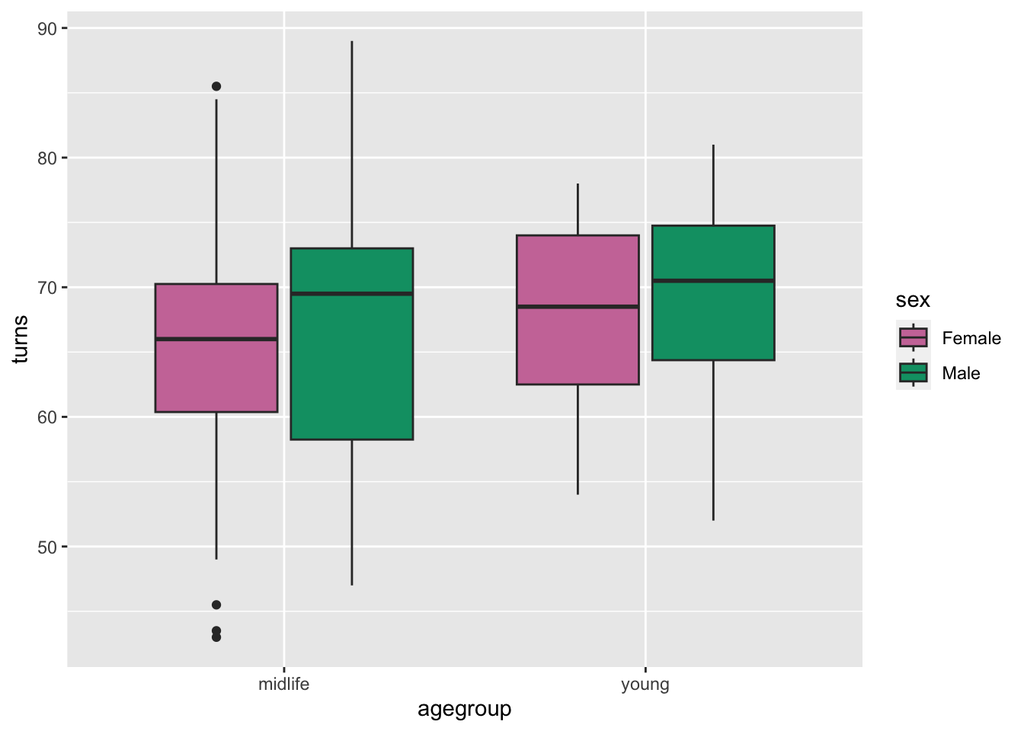

```r
masterDF %>% ggplot(aes(x=agegroup, y=turns, fill=sex)) +
  geom_boxplot() +
  scale_fill_manual(values=c("#CC79A7","#009E73"))
```

## Pause durations

**Normality**

Only young females had normally distributed data.

- **Midlife Males** : p = 0.0428795
- **Midlife females** : p = 0.0022837
- **Young males** : p = 0.0131184
- **Young females** : p = 0.6823661

**ANOVA and Effect Sizes**

Running a two factor anova with interactions. Main effect of age but not sex

```r
pauses_aov <- aov(formula=pauses ~ sex * agegroup, masterDF)
summary(pauses_aov)
```

```
##               Df   Sum Sq Mean Sq F value   Pr(>F)
## sex            1   357780  357780   3.099   0.0807 .
## agegroup       1  2661937 2661937  23.055 4.18e-06 ***
## sex:agegroup   1   418766  418766   3.627   0.0590 .
## Residuals    133 15356210  115460
## ---
## Signif. codes:  0 '***' 0.001 '**' 0.01 '*' 0.05 '.' 0.1 ' ' 1
```

Reporting effect sizes using eta squares

```r
etaSquared(pauses_aov)
```

```
##                   eta.sq eta.sq.part
## sex          0.002739325 0.003341497
## agegroup     0.141632355 0.147736425
## sex:agegroup 0.022281078 0.026546222
```

**Post Hoc**

Using Tukeys HSD

```r
 TukeyHSD(pauses_aov)
```

```
##   Tukey multiple comparisons of means
##     95% family-wise confidence level
##
## Fit: aov(formula = pauses ~ sex * agegroup, data = masterDF)
##
## $sex
##                  diff       lwr      upr     p adj
## Male-Female -107.6461 -228.6011 13.30902 0.0806522
##
## $agegroup
##                    diff       lwr       upr   p adj
## young-midlife -282.5367 -401.8118 -163.2616 6.8e-06
##
## $`sex:agegroup`
##                                   diff       lwr         upr     p adj
## Male:midlife-Female:midlife -144.34855 -359.2788   70.581672 0.3035538
## Female:young-Female:midlife -390.52573 -596.1320 -184.919460 0.0000135
## Male:young-Female:midlife   -293.40915 -505.0198  -81.798517 0.0024368
## Female:young-Male:midlife   -246.17718 -499.2463    6.891967 0.0597570
## Male:young-Male:midlife     -149.06060 -407.0318  108.910551 0.4383722
## Male:young-Female:young       97.11658 -153.1394  347.372560 0.7440490
```

**Plots**

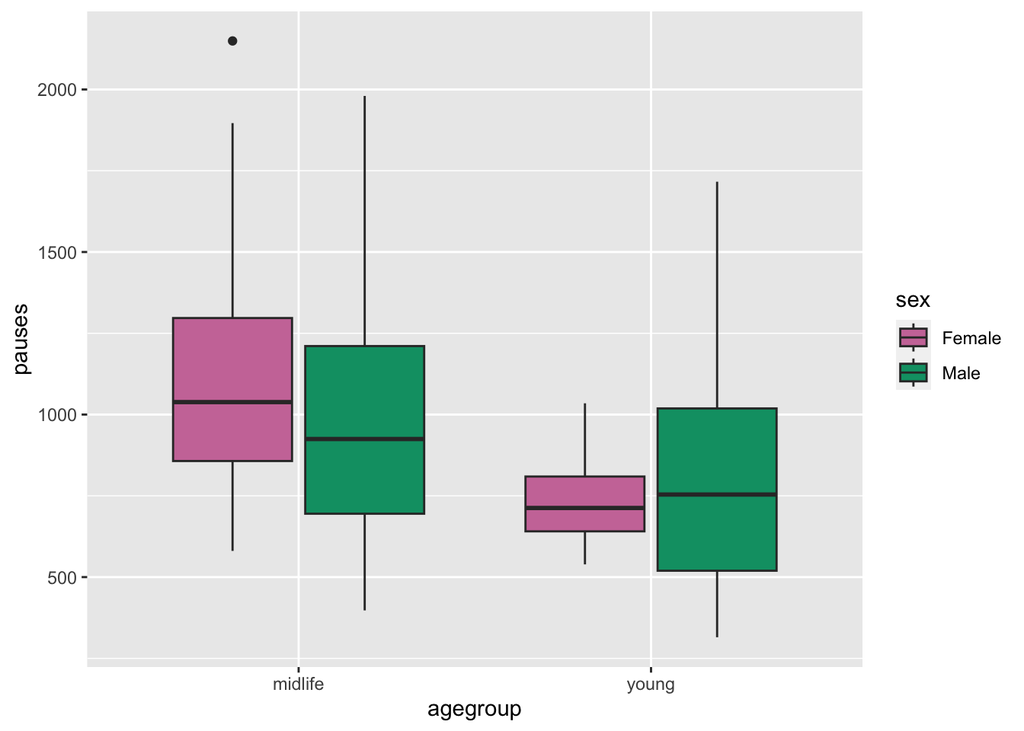

```r
masterDF %>% ggplot(aes(x=agegroup, y=pauses, fill=sex)) +
  geom_boxplot() +
  scale_fill_manual(values=c("#CC79A7","#009E73"))
```

## entropy

**Normality**

- **Midlife Males** : p = 0.0086614
- **Midlife females** : p = 0.105213
- **Young males** : p = 0.0807839
- **Young females** : p = 0.2216843

**ANOVA and Effect Sizes**

Running a two factor anova with interactions. Main effect of age but not sex

```r
entropy_aov <- aov(formula=entropy ~ sex * agegroup, masterDF)
summary(entropy_aov)
```

```
##               Df Sum Sq Mean Sq F value Pr(>F)
## sex            1  0.005   0.005   0.312  0.577
## agegroup       1  1.730   1.730 107.958 <2e-16 ***
## sex:agegroup   1  0.003   0.003   0.184  0.668
## Residuals    133  2.131   0.016
## ---
## Signif. codes:  0 '***' 0.001 '**' 0.01 '*' 0.05 '.' 0.1 ' ' 1
```

Reporting effect sizes using eta squares

```r
etaSquared(entropy_aov)
```

```
##                    eta.sq eta.sq.part
## sex          0.0123512370 0.021931257
## agegroup     0.4471156975 0.448036823
## sex:agegroup 0.0007634427 0.001384072
```

**Post Hoc**

Using Tukeys HSD

```r
 TukeyHSD(entropy_aov)
```

```
##   Tukey multiple comparisons of means
##     95% family-wise confidence level
##
## Fit: aov(formula = entropy ~ sex * agegroup, data = masterDF)
##
## $sex
##                   diff         lwr        upr     p adj
## Male-Female -0.0127257 -0.05778365 0.03233224 0.5773501
##
## $agegroup
##                     diff        lwr        upr p adj
## young-midlife -0.2277546 -0.2721867 -0.1833225     0
##
## $`sex:agegroup`
##                                    diff         lwr        upr     p adj
## Male:midlife-Female:midlife  0.04892314 -0.03114223  0.1289885 0.3879187
## Female:young-Female:midlife -0.23131432 -0.30790636 -0.1547223 0.0000000
## Male:young-Female:midlife   -0.20266979 -0.28149856 -0.1238410 0.0000000
## Female:young-Male:midlife   -0.28023747 -0.37451028 -0.1859647 0.0000000
## Male:young-Male:midlife     -0.25159293 -0.34769183 -0.1554940 0.0000000
## Male:young-Female:young      0.02864454 -0.06458032  0.1218694 0.8545610
```

**Plots**

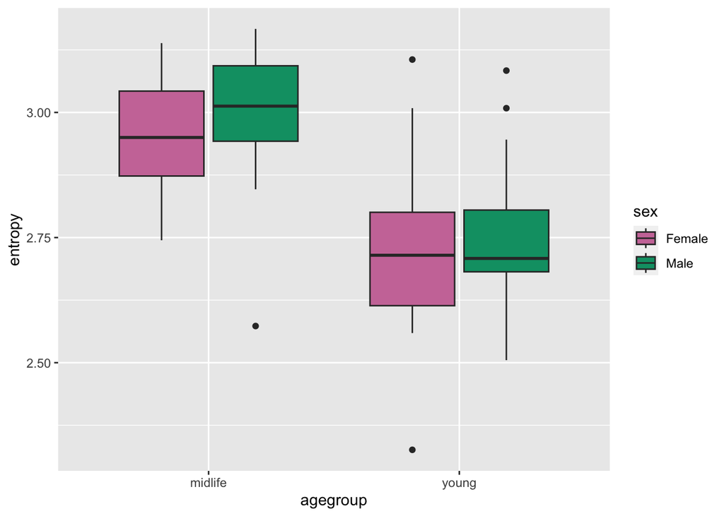

```r
masterDF %>% ggplot(aes(x=agegroup, y=entropy, fill=sex)) +
  geom_boxplot() +
  scale_fill_manual(values=c("#CC79A7","#009E73"))
```